# Dow Data Challenge: LARS Regression

### CHE 891 — Week 2

We apply **Least Angle Regression (LARS)** to the Dow impurity dataset. LARS is well-suited here because:

- The 42 process variables are strongly collinear
- We want a **sparse** model — only the most relevant sensors
- LARS produces the full regularization path at the cost of one OLS fit

```python
import pandas as pd
import numpy as np
from pylab import *
from sklearn.preprocessing import StandardScaler
from sklearn.pipeline import Pipeline
from sklearn.compose import TransformedTargetRegressor
from sklearn.linear_model import Lars, lars_path
import warnings
warnings.filterwarnings('ignore')
```

## 1. Load Data

```python
training_url = 'http://egr.msu.edu/~scb/courses/EGR891/dow_training_clean.csv'

df_train = pd.read_csv(training_url, parse_dates=['Date'])
print(f"Training: {df_train.shape}")
df_train.head()
```

```
Training: (1927, 48)
```

|  | Date | x1:Primary Column Reflux Flow | x2:Primary Column Tails Flow | x3:Input to Primary Column Bed 3 Flow | x4:Input to Primary Column Bed 2 Flow | x5:Primary Column Feed Flow from Feed Column | x6:Primary Column Make Flow | x7:Primary Column Base Level | x8:Primary Column Reflux Drum Pressure | x9:Primary Column Condenser Reflux Drum Level | ... | x38: Feed Column Calculated DP | x39: Feed Column Steam Flow | x40: Feed Column Tails Flow | Avg_Reactor_Outlet_Impurity | Avg_Delta_Composition Primary Column | y:Impurity | Primary Column Reflux/Feed Ratio | Primary Column Make/Reflux Ratio | x16x17L | x16x17H |
| --- | --- | --- | --- | --- | --- | --- | --- | --- | --- | --- | --- | --- | --- | --- | --- | --- | --- | --- | --- | --- | --- |
| 0 | 2015-12-01 00:00:00 | 327.813 | 45.7920 | 2095.06 | 2156.01 | 98.5005 | 95.4674 | 54.3476 | 41.0121 | 52.2353 | ... | 66.6604 | 8.68813 | 99.9614 | 5.38024 | 1.49709 | 1.77833 | 3.32803 | 0.291226 | 23.4202 | 52.6953 |
| 1 | 2015-12-01 09:00:00 | 327.686 | 45.8192 | 2109.75 | 2185.82 | 98.8448 | 95.5414 | 54.0806 | 41.0029 | 53.0875 | ... | 65.5845 | 8.69685 | 100.2790 | 5.31385 | 1.51268 | 1.70012 | 3.31516 | 0.291564 | 22.6707 | 53.3360 |
| 2 | 2015-12-01 14:00:00 | 322.439 | 46.0614 | 2108.64 | 2124.04 | 96.8568 | 94.1683 | 54.5115 | 40.9982 | 53.3624 | ... | 69.2825 | 8.70710 | 99.8578 | 5.29914 | 1.52085 | 1.41000 | 3.32903 | 0.292050 | 25.4557 | 53.9291 |
| 3 | 2015-12-01 15:00:00 | 322.402 | 45.9821 | 2104.28 | 2233.15 | 96.8940 | 94.1798 | 54.2862 | 40.9888 | 53.2537 | ... | 67.9772 | 8.72056 | 99.9187 | 5.32702 | 1.51294 | 1.44087 | 3.32737 | 0.292119 | 25.7638 | 53.4808 |
| 4 | 2015-12-01 20:00:00 | 330.082 | 45.9936 | 2104.54 | 2171.53 | 98.4124 | 96.2888 | 55.2908 | 40.9888 | 53.3826 | ... | 66.7390 | 8.69239 | 99.8563 | 5.44890 | 1.51592 | 1.68766 | 3.35407 | 0.291712 | 22.3133 | 52.8688 |

5 rows × 48 columns

## 2. Prepare X and y

```python
feat_cols = [c for c in df_train.columns if c.startswith('x')]

X_train     = df_train[feat_cols].values
y_train     = df_train['y:Impurity'].values

print(f"Features: {len(feat_cols)}")
print(f"X_train: {X_train.shape}  y_train: {y_train.shape}")
```

```
Features: 42
X_train: (1927, 42)  y_train: (1927,)
```

## 3. Pipe and Model

We use a `Pipeline` (scaling inside) and `TransformedTargetRegressor` (softplus transform on $y$).

The **softplus inverse** $z = \ln(e^y - 1)$ maps positive $y$ to the real line before fitting. Predictions are automatically inverse-transformed back via softplus $y = \ln(1 + e^z)$.

```python
def softplus(z):
    return np.logaddexp(z, 0)       # log(1 + exp(z)), numerically stable

def softplus_inv(y):
    return np.log(np.expm1(y))      # log(exp(y) - 1), valid for y > 0

pipe = Pipeline([
    ('scaler', StandardScaler()),
    ('lars',   Lars(n_nonzero_coefs=len(feat_cols)))
])

model = TransformedTargetRegressor(
    regressor=pipe,
    func=softplus_inv,      # y → z for training
    inverse_func=softplus   # z → y for prediction
)
model.fit(X_train, y_train)
print("Model fitted.")
```

```
Model fitted.
```

## 4. LARS Path

`lars_path` computes the full regularization path directly on scaled $X$ and transformed $y$. It returns `(alphas, active, coefs)` where `coefs` has shape `(n_features, n_steps)`.

```python
X_s = model.regressor_['scaler'].transform(X_train)
z_train = softplus_inv(y_train)

# max_iter=len(feat_cols) stops at the OLS solution (same as Lars(n_nonzero_coefs=p))
_, _, path = lars_path(X_s, z_train, method='lar', max_iter=len(feat_cols))
print(f"Steps in path: {path.shape[1]}")
print(f"Features:      {path.shape[0]}")
```

```
Steps in path: 43
Features:      42
```

## 5. LARS Path Plot

Each line is one sensor variable. Variables enter the active set one at a time as the L1 norm of the coefficient vector grows (left = sparse, right = OLS).

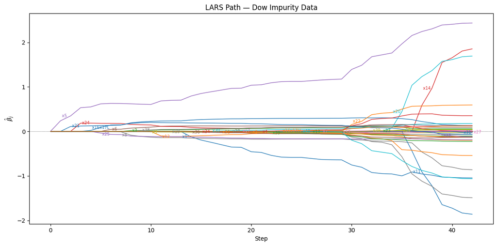

```python
short_names = [c.split(':')[0] for c in feat_cols]
steps = np.arange(path.shape[1])

figure(figsize=(12, 6))
line_colors = [plot(steps, path[i, :], lw=1)[0].get_color()
               for i in range(len(short_names))]

axhline(0, color='k', lw=0.5, ls=':')

# Label each variable at its entry step
for i, name in enumerate(short_names):
    nz = np.where(path[i, :] != 0)[0]
    if len(nz) > 0:
        step = nz[0]
        y_pos = path[i, min(step + 1, path.shape[1] - 1)]
        text(step, y_pos, f' {name}',
             fontsize=7, color=line_colors[i], va='center')

xlabel('Step')
ylabel(r'$\hat{\beta}_j$')
title('LARS Path — Dow Impurity Data')
tight_layout()
show()
```

## 6. Variable Entry Order

The order in which variables enter the active set reflects their marginal correlation with the residual — a natural variable importance ranking.

```python
# Find the step at which each variable first becomes nonzero
entry_step = []
for i in range(path.shape[0]):
    nz = np.where(path[i, :] != 0)[0]
    entry_step.append(nz[0] if len(nz) > 0 else path.shape[1])

order = np.argsort(entry_step)

print("Variable entry order:")
for rank, idx in enumerate(order):
    if entry_step[idx] < path.shape[1]:
        print(f"  {rank+1:2d}.  {feat_cols[idx]}")
```

```
Variable entry order:
   1.  x5:Primary Column Feed Flow from Feed Column
   2.  x21:Primary Column Bed 1 Temperature
   3.  x24: Secondary Column Tails Flow
   4.  x16x17L
   5.  x25: Secondary Column Tray DP
   6.  x6:Primary Column Make Flow
   7.  x8:Primary Column Reflux Drum Pressure
   8.  x3:Input to Primary Column Bed 3 Flow
   9.  x38: Feed Column Calculated DP
  10.  x9:Primary Column Condenser Reflux Drum Level
  11.  x12:Primary Column Bed3 DP
  12.  x18:Primary Column Bed 4 Temperature
  13.  x1:Primary Column Reflux Flow
  14.  x36: Feed Column Recycle Flow
  15.  x34: Secondary Column Tails Temperature
  16.  x30: Secondary Column Bed 1 Temperature
  17.  x32: Secondary Column Tray 2 Temperature
  18.  x28: Secondary Column Base Temperature
  19.  x17:Primary Column Tails Temperature 1
  20.  x2:Primary Column Tails Flow
  21.  x4:Input to Primary Column Bed 2 Flow
  22.  x33: Secondary Column Tray 1 Temperature
  23.  x16x17H
  24.  x40: Feed Column Tails Flow
  25.  x13:Primary Column Bed4 DP
  26.  x7:Primary Column Base Level
  27.  x37: Feed Column Tails Flow to Primary Column
  28.  x22: Secondary Column Base Concentration
  29.  x39: Feed Column Steam Flow
  30.  x23: Flow from Input to Secondary Column
  31.  x20:Primary Column Bed 2 Temperature
  32.  x29: Secondary Column Tray 3 Temperature
  33.  x11:Primary Column Bed2 DP
  34.  x14:Primary Column Base Pressure
  35.  x35: Secondary Column Tails Concentration
  36.  x31: Secondary Column Bed 2 Temperature
  37.  x27: Secondary Column Base Pressure
```

## 7. $C_p$ Model Selection

Mallows' $C_p$ estimates prediction risk at each step of the LARS path:

$$C_p = \frac{\text{RSS}_p}{\hat{\sigma}^2} - n + 2p$$

where $n$ is the number of training observations, $p$ is the number of active variables plus intercept, and $\hat{\sigma}^2$ is estimated from the full OLS model (last step).

```python
n = len(z_train)
z_bar = z_train.mean()

# Predictions at each step: intercept = z_bar (X_s is zero-mean)
z_hat = z_bar + X_s @ path          # shape (n, n_steps)
rss = np.sum((z_train[:, None] - z_hat) ** 2, axis=0)

# Number of parameters at each step (nonzero coefficients + intercept)
p_s = (path != 0).sum(axis=0) + 1

# sigma^2 from OLS (last step)
sigma2 = rss[-1] / (n - p_s[-1])
print(f"sigma^2 = {sigma2:.4f},  sigma = {np.sqrt(sigma2):.4f}")

Cp = rss / sigma2 - n + 2 * p_s

best_step = np.argmin(Cp)
print(f"Optimal step: {best_step}  ({int(p_s[best_step]) - 1} variables,  Cp = {Cp[best_step]:.1f})")
```

```
sigma^2 = 0.4027,  sigma = 0.6345
Optimal step: 31  (28 variables,  Cp = 11.2)
```

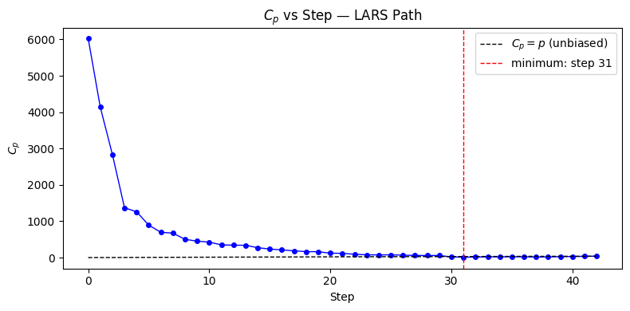

```python
steps = np.arange(path.shape[1])

figure(figsize=(8, 4))
plot(steps, Cp, 'b-o', ms=4, lw=1)
plot(steps, p_s, 'k--', lw=1, label=r'$C_p = p$ (unbiased)')
axvline(best_step, color='r', ls='--', lw=1, label=f'minimum: step {best_step}')
xlabel('Step')
ylabel(r'$C_p$')
title(r'$C_p$ vs Step — LARS Path')
legend()
tight_layout()
show()
```

## 8. Training and Validation Fit

Refit the model using only the `best_step` variables selected by $C_p$, then evaluate $R^2$ on both the training and validation sets.

```python
# Load validation data
validation_url = 'http://egr.msu.edu/~scb/courses/EGR891/dow_validation_clean.csv'
df_val = pd.read_csv(validation_url, parse_dates=['Date'])
print(f"Validation: {df_val.shape}")

X_val = df_val[feat_cols].values
y_val = df_val['y:Impurity'].values
```

```
Validation: (5891, 48)
```

```python
from sklearn.metrics import r2_score

# Re-compute training path
X_s_train = model.regressor_['scaler'].transform(X_train)
z_train = softplus_inv(y_train)
_, _, path_train = lars_path(X_s_train, z_train, method='lar', max_iter=len(feat_cols))


n_train = len(z_train)
z_bar_train = z_train.mean()
z_hat_train = z_bar_train + X_s_train @ path_train
rss_train = np.sum((z_train[:, None] - z_hat_train) ** 2, axis=0)
p_s = (path_train != 0).sum(axis=0) + 1
sigma2 = rss_train[-1] / (n_train - p_s[-1])
Cp = rss_train / sigma2 - n_train + 2 * p_s
best_step = np.argmin(Cp)

print(f"Best step from training: {best_step} ({int(p_s[best_step]) - 1} variables)")
```

```
Best step from training: 31 (28 variables)
```

```python
# Apply training model to validation data
X_s_val = model.regressor_['scaler'].transform(X_val)
z_val = softplus_inv(y_val)

# Predict using training coefficients at best_step
z_bar_train = z_train.mean()
coef_best = path_train[:, best_step]
z_pred_val = z_bar_train + X_s_val @ coef_best

# Transform back to original scale
y_pred_val = softplus(z_pred_val)

# Evaluate
r2_val = r2_score(y_val, y_pred_val)
r2_train = r2_score(y_train, softplus(z_bar_train + X_s_train @ coef_best))

print(f"Training R²:   {r2_train:.4f}")
print(f"Validation R²: {r2_val:.4f}")
```

```
Training R²:   0.7747
Validation R²: 0.3378
```

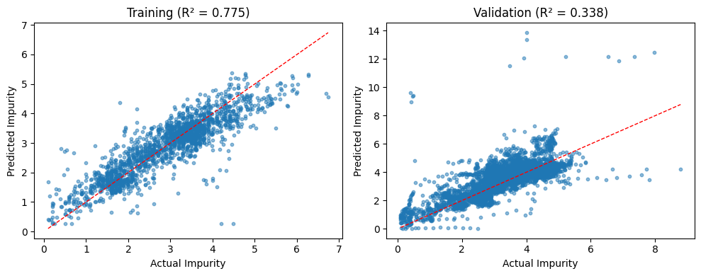

```python
# Parity plot: predicted vs actual
figure(figsize=(10, 4))

subplot(1, 2, 1)
scatter(y_train, softplus(z_bar_train + X_s_train @ coef_best), alpha=0.5, s=10)
plot([y_train.min(), y_train.max()], [y_train.min(), y_train.max()], 'r--', lw=1)
xlabel('Actual Impurity')
ylabel('Predicted Impurity')
title(f'Training (R² = {r2_train:.3f})')

subplot(1, 2, 2)
scatter(y_val, y_pred_val, alpha=0.5, s=10)
plot([y_val.min(), y_val.max()], [y_val.min(), y_val.max()], 'r--', lw=1)
xlabel('Actual Impurity')
ylabel('Predicted Impurity')
title(f'Validation (R² = {r2_val:.3f})')

tight_layout()
show()
```

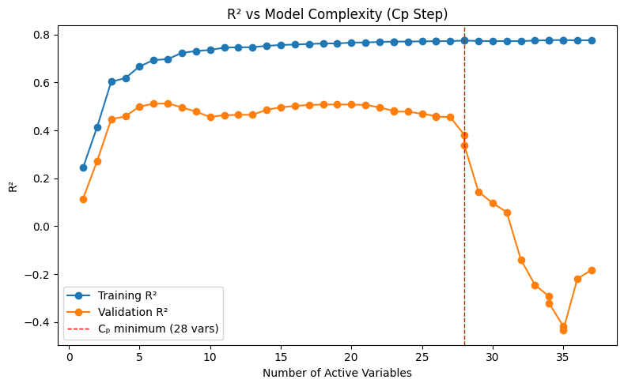

```python
# Analyze how R² changes as a function of Cp-selected step (model complexity)
r2_train_list = []
r2_val_list = []
num_vars = []

for step in range(path_train.shape[1]):
    coef_step = path_train[:, step]
    n_active = np.sum(coef_step != 0)
    if n_active == 0:
        # Skip degenerate model (no variables)
        r2_train_list.append(np.nan)
        r2_val_list.append(np.nan)
        num_vars.append(0)
        continue

    # Training predictions
    y_pred_train = softplus(z_bar_train + X_s_train @ coef_step)
    r2_train_list.append(r2_score(y_train, y_pred_train))

    # Validation predictions
    y_pred_val = softplus(z_bar_train + X_s_val @ coef_step)
    r2_val_list.append(r2_score(y_val, y_pred_val))
    num_vars.append(n_active)

figure(figsize=(8, 5))
plot(num_vars, r2_train_list, label='Training R²', marker='o')
plot(num_vars, r2_val_list, label='Validation R²', marker='o')
axvline(num_vars[best_step], color='r', ls='--', lw=1, label=f'Cₚ minimum ({num_vars[best_step]} vars)')
xlabel('Number of Active Variables')
ylabel('R²')
title('R² vs Model Complexity (Cp Step)')
legend()
tight_layout()
show()
```

```python
# Refit with the optimal number of variables and save
import joblib

best_n_vars = int(p_s[best_step]) - 1   # e.g. 10

pipe_best = Pipeline([
    ('scaler', StandardScaler()),
    ('lars',   Lars(n_nonzero_coefs=best_n_vars))
])
model_best = TransformedTargetRegressor(
    regressor=pipe_best,
    func=softplus_inv,
    inverse_func=softplus
)
model_best.fit(X_train, y_train)

joblib.dump(model_best, 'lars_dow_A10.pkl')
print("Model saved.")
```

```
Model saved.
```

HW answer for question 2:

My model massively underperformes compared to Qin et al., which is dissapointing. Based on the training and validation R^2 values, I am significantly overfitting my system; not surprising, since I am using many more variables than Qin et al. did. I think going back and optimizing the variable number selection would improve this, but I am still behind on the training set R^2 value as well. Compared to the PLS, LARS performes much better, which is another deviation from Qin et al. who reported similar and complementary performance from both systems. One of the primary issues I run into is the false prediction of impurity spikes in the validation prediction, a phenomena which may be mitigated by OBL.